# Projet extreme values

MAHAMAT HASSAN ISSA

2023-07-28

# Précipitations maximales annuelles (inches) pour un pluviomètre à Fort Collins, Colorado à partir de 1900 jusqu’en 1999. La variable d’intérêt est la quantité maximale annuelle de précipitations en inches :Préc.

```r
x=ftcanmax$Prec
x
```

```
##   [1] 239 232 434  85 302 174 170 121 193 168 148 116 132 132 144 183 223  96
##  [19] 298  97 116 146  84 230 138 170 117 115 132 125 156 124 189 193  71 176
##  [37] 105  93 354  60 151 160 219 142 117  87 223 215 108 354 213 306 169 184
##  [55]  71  98  96 218 176 121 161 321 102 269  98 271  95 212 151 136 240 162
##  [73]  71 110 285 215 103 443 185 199 115 134 297 187 203 146  94 129 162 112
##  [91] 348  95 249 103 181 152 135 463 183 241
```

```r
length(x)
```

```
## [1] 100
```

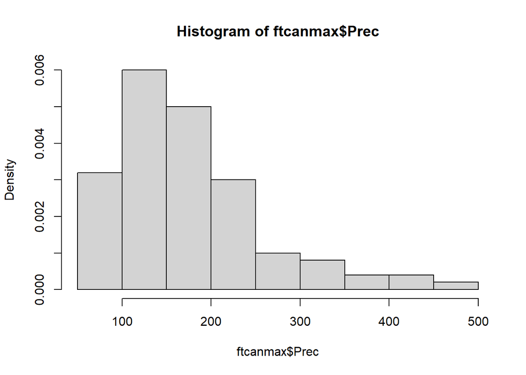

```r
hist=hist(ftcanmax$Prec,freq=F)
```

```r
# on voit la répartition de notre echantillon sur l'histogramme
```

## I) GEV:La distribution généralisée des valeurs extrêmes

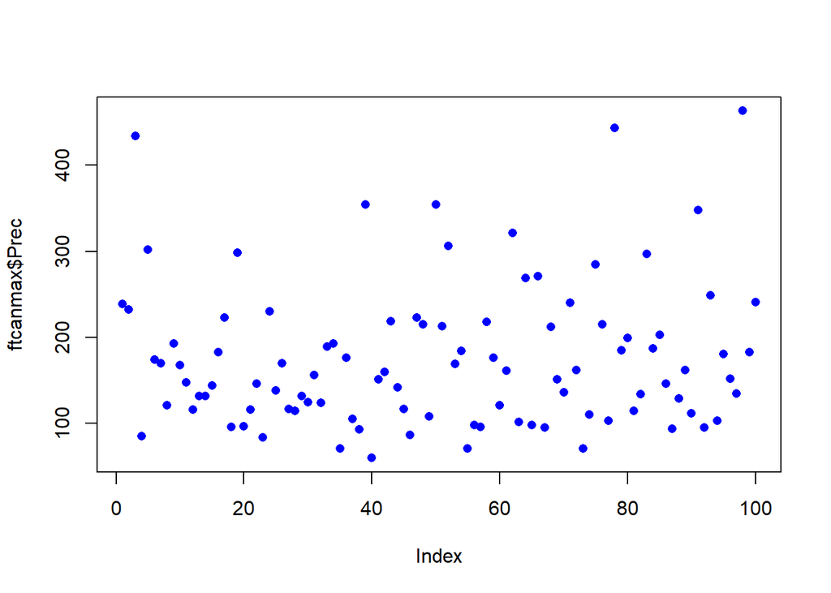

# On voit la distribution des points sur l’axe des abscisses et sur l’axe des ordonnées(ftcanmax$Prec).On remarque sur l’axe des ordonnées qu’il ya trois points qui sont situés en dessus de 400 et les autres points en dessous de 400.

```r
# 1)using MLE( méthode de maximum de vraissemblance)
FitxMle=fevd(x,type="GEV",method="MLE")
FitxMle
```

```
##
## fevd(x = x, type = "GEV", method = "MLE")
##
## [1] "Estimation Method used: MLE"
##
##
##  Negative Log-Likelihood Value:  565.4816
##
##
##  Estimated parameters:
##  location     scale     shape
## 134.66520  53.28089   0.17363
##
##  Standard Error Estimates:
##   location      scale      shape
## 6.16877130 4.87901653 0.09195688
##
##  Estimated parameter covariance matrix.
##            location       scale        shape
## location 38.0537393 17.06709037 -0.208376947
## scale    17.0670904 23.80480234 -0.086937257
## shape    -0.2083769 -0.08693726  0.008456068
##
##  AIC = 1136.963
##
##  BIC = 1144.779
```

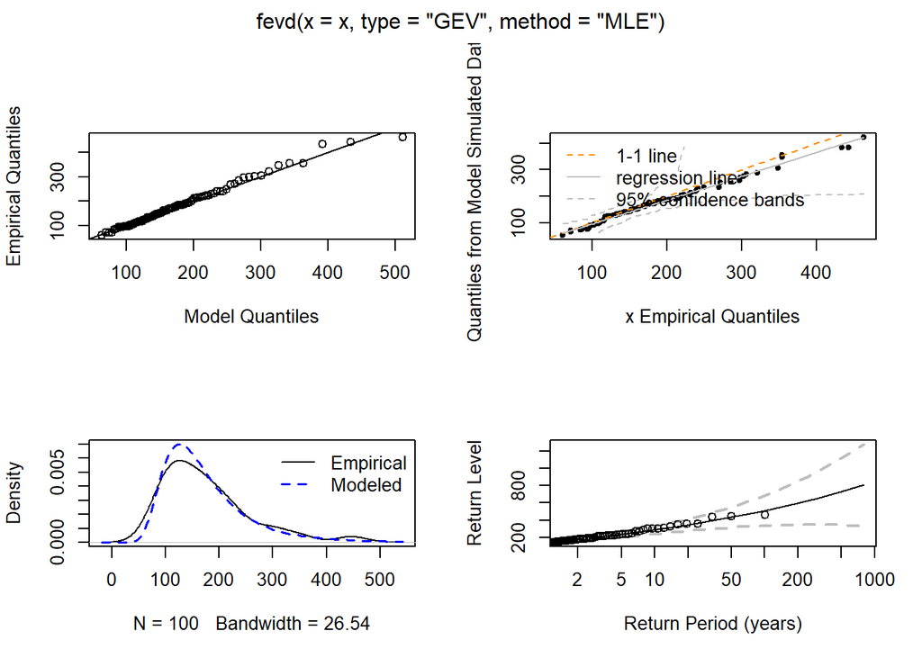

```r
plot(FitxMle)
```

# Sur le graphique en bas à droite,on voit que tous les points sont dans l’intervalle de confiance et assez bien alignés sur la courbe, on a un bon ajustement de notre modèle à nos données. sur les graphiques en haut à gauche et en bas à gauche on voit un bon ajustement de notre modèle à nos données à part quelques points sous estimés.

```r
ci(FitxMle,type="parameter")
```

```
## fevd(x = x, type = "GEV", method = "MLE")
##
## [1] "Normal Approx."
##
##           95% lower CI  Estimate 95% upper CI
## location 122.574631358 134.66520  146.7557705
## scale     43.718193944  53.28089   62.8435873
## shape     -0.006602197   0.17363    0.3538622
```